# AR SpTimer Seattle

NOTEBOOK CON MODELO Autoregressive (AR) DE SPTIMER

```r
setwd("C:/Users/CINTIA/Desktop/ProyectoFindeMaster")
STdata <- read.table("SerieTotal2016_ext_selected.csv", sep=",", header=T)
library(dplyr)
if(!require("spTimer")){
  install.packages("spTimer")
  library("spTimer")
}
STdata <- STdata %>%
  mutate(
    Month = format(as.POSIXlt(timestamp), '%m'),
    Day =  format(as.POSIXlt(timestamp), '%d'),
    Year = format(as.POSIXlt(timestamp),'%Y'),
    Hour = format(as.POSIXlt(timestamp),'%H'),
    day_week = format(as.POSIXlt(timestamp),'%u')
  )
STdata$monday <- ifelse(STdata$day_week == "1", 1, 0)
STdata$tuesday <- ifelse(STdata$day_week == "2", 2, 0)
STdata$wednesday <- ifelse(STdata$day_week == "3", 3, 0)
STdata$thursday <- ifelse(STdata$day_week == "4", 4, 0)
STdata$friday <- ifelse(STdata$day_week == "5", 5, 0)
STdata$saturday <- ifelse(STdata$day_week == "6", 6, 0)
STdata$Month=as.integer(STdata$Month)
STdata$Day=as.integer(STdata$Day)
STdata$Year=as.integer(STdata$Year)
STdata$Hour=as.integer(STdata$Hour)
STdata_final <- STdata
#STdata_final <- select(STdata, element_key, latitude,longitude, Month, Day, Hour, road_temp, monday, tuesday, wednesday, thursday, friday, tmin, occupation_perc)
head(STdata_final)
```

|  | day_year | element_key | hour | timestamp | occupation_perc | latitude | longitude | paid_parking_area | prcp | tmax | tmin | air_temp | road_temp | poi | baseball | tennis | basket | soccer | event | no2 | co | pm2_5 | o3 | Month | Day | Year | Hour | day_week | monday | … |
| --- | --- | --- | --- | --- | --- | --- | --- | --- | --- | --- | --- | --- | --- | --- | --- | --- | --- | --- | --- | --- | --- | --- | --- | --- | --- | --- | --- | --- | --- | --- |
| 1 | 1 | 1037 | 8 | 2016-01-01 08:00:00 | 5.770 | 47.62148 | -122.3555 | Uptown | 0 | 7.78 | -2.22 | 0.57 | -1.07 | 0 | 0 | 0 | 0 | 0 | 0 | 75.26267 | 858.75 | 26.685 | 61 | 1 | 1 | 2016 | 8 | 5 | 0 | … |
| 2 | 1 | 1037 | 9 | 2016-01-01 09:00:00 | 7.695 | 47.62148 | -122.3555 | Uptown | 0 | 7.78 | -2.22 | 2.53 | -0.83 | 0 | 0 | 0 | 0 | 0 | 0 | 75.26267 | 858.75 | 26.685 | 61 | 1 | 1 | 2016 | 9 | 5 | 0 | … |
| 3 | 1 | 1037 | 10 | 2016-01-01 10:00:00 | 9.615 | 47.62148 | -122.3555 | Uptown | 0 | 7.78 | -2.22 | 4.33 | -0.40 | 0 | 0 | 0 | 0 | 0 | 0 | 75.26267 | 858.75 | 26.685 | 61 | 1 | 1 | 2016 | 10 | 5 | 0 | … |
| 4 | 1 | 1037 | 11 | 2016-01-01 11:00:00 | 13.465 | 47.62148 | -122.3555 | Uptown | 0 | 7.78 | -2.22 | 5.49 | 1.02 | 0 | 0 | 0 | 0 | 0 | 0 | 75.26267 | 858.75 | 26.685 | 61 | 1 | 1 | 2016 | 11 | 5 | 0 | … |
| 5 | 1 | 1037 | 12 | 2016-01-01 12:00:00 | 19.230 | 47.62148 | -122.3555 | Uptown | 0 | 7.78 | -2.22 | 5.92 | 2.53 | 0 | 0 | 0 | 0 | 0 | 0 | 75.26267 | 858.75 | 26.685 | 61 | 1 | 1 | 2016 | 12 | 5 | 0 | … |
| 6 | 1 | 1037 | 13 | 2016-01-01 13:00:00 | 25.000 | 47.62148 | -122.3555 | Uptown | 0 | 7.78 | -2.22 | 5.94 | 2.73 | 0 | 0 | 0 | 0 | 0 | 0 | 75.26267 | 858.75 | 26.685 | 61 | 1 | 1 | 2016 | 13 | 5 | 0 | … |

### The AR models:

## Spatial prediction/interpolation

# Lectura de datos

En este punto, vamos a apartar el día 1 de abril del año 2016 que es el que comprende nuestro dataset como día de predicción.

```r
s<-c('1037','1045','1046','1433','9510','11878','12289','13549','13793','14677',
     '18622','24557','30698','34938','35681','35682','37134','37177','41030','59958',
     '62458','63125','69098','76961','76962','79741','81117','85381','85385','86449')
DataFit<-spT.subset(data=STdata_final, var.name=c("element_key"), s=s)
DataFit<-subset(DataFit, with(DataFit, !(Day %in% c(1) & Month == 4)))
DataValPred<-spT.subset(data=STdata_final, var.name=c("element_key"), s=s)
DataValPred<-subset(DataValPred, with(DataValPred, !(Day %in% c(1) & Month == 4)))
```

Lo siguiente Va a ser ejecutar el modelo Markov chain Monte Carlo(MCMC) usando el algoritmo Gibbs sampler.

```r
set.seed(11)
post.ar <- spT.Gibbs(formula=occupation_perc ~Hour+tmin+road_temp+monday+tuesday+wednesday+thursday+friday,
                     data=DataFit,
                     model="AR",
                     coords=~longitude+latitude,
                     distance.method="geodetic:km",
                     scale.transform="SQRT",
                     tol.dist=0.001,
                     spatial.decay=spT.decay(distribution=Gamm(2,1),tuning=0.01))
```

```
 Output: AR models
---------------------------------------------------------------
 Sampled: 5000 of 5000, 100.00%.
 Batch Acceptance Rate (phi): 16.76%
 Checking Parameters:
   phi: 16.5152, rho: 0.6425, sig2eps: 0.0050, sig2eta: 2.4794
   beta[1]: 4.1109   beta[2]: -0.1786   beta[3]: -0.0319   beta[4]: 0.0219   beta[5]: -0.1720   beta[6]: -0.0721   beta[7]: -0.0370   beta[8]: -0.0241   beta[9]: -0.0097
---------------------------------------------------------------
```

A Continuación:

1. Definimos las coordinadas de predicción
2. Hacemos una predicción espacial usando spT.Gibbs output
3. Hacemos una validación de criterio

```r
# Define prediction coordinates
pred.coords<-as.matrix(unique(cbind(DataValPred[,2:3])))
# Spatial prediction using spT.Gibbs output
set.seed(11)
pred.ar <- predict(post.ar, newdata=DataValPred, newcoords=pred.coords)
```

```
 Prediction: AR models
#
# Tolerance Limit (unit): 2
# Location distances are alright
#
-------------------------------------------------
  Sampled: 400 of 4000, 10.00%
-------------------------------------------------
-------------------------------------------------
  Sampled: 800 of 4000, 20.00%
-------------------------------------------------
-------------------------------------------------
  Sampled: 1200 of 4000, 30.00%
-------------------------------------------------
-------------------------------------------------
  Sampled: 1600 of 4000, 40.00%
-------------------------------------------------
-------------------------------------------------
  Sampled: 2000 of 4000, 50.00%
-------------------------------------------------
-------------------------------------------------
  Sampled: 2400 of 4000, 60.00%
-------------------------------------------------
-------------------------------------------------
  Sampled: 2800 of 4000, 70.00%
-------------------------------------------------
-------------------------------------------------
  Sampled: 3200 of 4000, 80.00%
-------------------------------------------------
-------------------------------------------------
  Sampled: 3600 of 4000, 90.00%
-------------------------------------------------
-------------------------------------------------
  Sampled: 4000 of 4000, 100.00%
-------------------------------------------------
##
# Predicted samples and summary statistics are given.
# nBurn =  1000 . Iterations =  5000 .
##
##
# Elapsed time: 6 Min. 38.71 Sec.
##
```

```r
print(pred.ar)
```

```
--------------------------------------
Spatial prediction with Model: AR
Covariance function: exponential
Distance method: geodetic:km
Computation time:  6  - Mins. 38.71  - Sec.
--------------------------------------
```

```r
names(pred.ar)
```

```
 [1] "pred.samples"         "pred.coords"          "distance.method"      "Distance.matrix.pred" "cov.fnc"              "predN"
 [7] "Mean"                 "Median"               "SD"                   "Low"                  "Up"                   "computation.time"
[13] "model"                "type"
```

```r
# validation criteria
spT.validation(DataValPred$occupation_perc,c(pred.ar$Mean))
```

```
     MSE     RMSE      MAE     MAPE     BIAS    rBIAS    rMSEP
299.7005  17.3119  13.8982  73.2293  -1.3484  -0.0489   0.9555
```

Para el siguiente paso, podemos elegir: 1. Hacer una predicción temporal en localizaciones NO OBSERVADAS 2. Hacer una predicción temporal en localizaciones OBSERVADAS Nuestro interés es la predicción de la ocupación de los parquimetros seleccionados.

Aún así, he probado el codigo de predicción temporal en localizaciones NO OBSERVADAS y el resultado es el mismo.

```r
##
## Temporal prediction/forecast
## 2. In the observed/fitted locations
##
# Read data
DataFitFore<-spT.subset(data=STdata_final, var.name=c("element_key"), s=s)
DataFitFore<-subset(DataFitFore, with(DataFitFore, (Day %in% c(1) & Month == 4)))
# define forecast coordinates
fore.coords<-as.matrix(unique(cbind(DataFitFore[,2:3])))
# Two-step ahead forecast, i.e., in day 61 and 62
# in the unobserved locations using output from spT.Gibbs
set.seed(11)
fore.ar <- predict(post.ar, newdata=DataFitFore, newcoords=fore.coords,
                   type="temporal", foreStep=12, tol.dist=0.001)
```

```
 Forecast: AR models
-------------------------------------------------
  Sampled: 400 of 4000, 10.00%
-------------------------------------------------
-------------------------------------------------
  Sampled: 800 of 4000, 20.00%
-------------------------------------------------
-------------------------------------------------
  Sampled: 1200 of 4000, 30.00%
-------------------------------------------------
-------------------------------------------------
  Sampled: 1600 of 4000, 40.00%
-------------------------------------------------
-------------------------------------------------
  Sampled: 2000 of 4000, 50.00%
-------------------------------------------------
-------------------------------------------------
  Sampled: 2400 of 4000, 60.00%
-------------------------------------------------
-------------------------------------------------
  Sampled: 2800 of 4000, 70.00%
-------------------------------------------------
-------------------------------------------------
  Sampled: 3200 of 4000, 80.00%
-------------------------------------------------
-------------------------------------------------
  Sampled: 3600 of 4000, 90.00%
-------------------------------------------------
-------------------------------------------------
  Sampled: 4000 of 4000, 100.00%
-------------------------------------------------
##
# Forecast samples and summary statistics are given.
# nBurn =  0 . Iterations =  4000 .
##
##
# Elapsed time: 38.79 Sec.
##
```

```r
print(fore.ar)
```

```
--------------------------------------
Temporal prediction/forecast with Model: AR
Covariance function: exponential
Distance method: geodetic:km
Computation time:  38.79  - Sec.
--------------------------------------
```

```r
names(fore.ar)
```

```
 [1] "fore.samples"     "fore.coords"      "distance.method"  "cov.fnc"          "obsData"          "fittedData"       "residuals"
 [8] "Mean"             "Median"           "SD"               "Low"              "Up"               "computation.time" "model"
[15] "type"
```

Vamos a validar las predicciones

```r
# validation criteria
spT.validation(DataValPred$occupation_perc,c(pred.ar$Mean))
```

```
     MSE     RMSE      MAE     MAPE     BIAS    rBIAS    rMSEP
299.7005  17.3119  13.8982  73.2293  -1.3484  -0.0489   0.9555
```

Hacemos plotting utilizando la librería Forecast

Parquímetro 1037:

```r
# Use of "forecast" class
library(forecast)
tmp<-as.forecast.object(fore.ar, site=1) # Para el parquímetro 1037
```

```
Forecast for site: 1
```

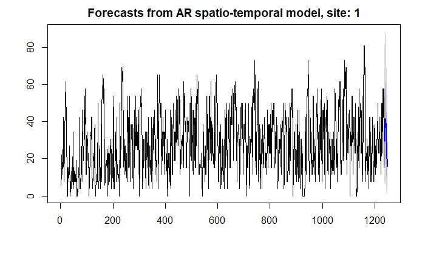

```r
plot(tmp)
```

Parquímetro 1045:

```r
tmp<-as.forecast.object(fore.ar, site=2) # Para el parquímetro 1045
```

```
Forecast for site: 2
```

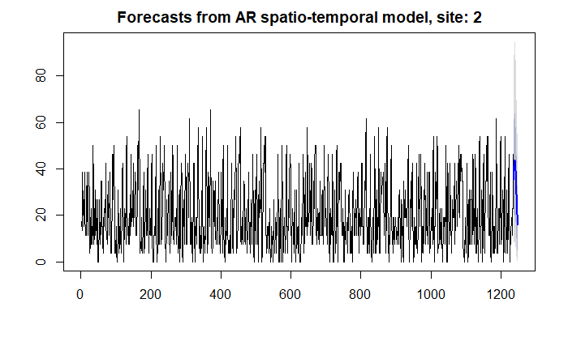

```r
plot(tmp)
```

Parquímetro 86449:

```r
tmp<-as.forecast.object(fore.ar, site=30) # Para el parquímetro 1045
```

```
Forecast for site: 30
```

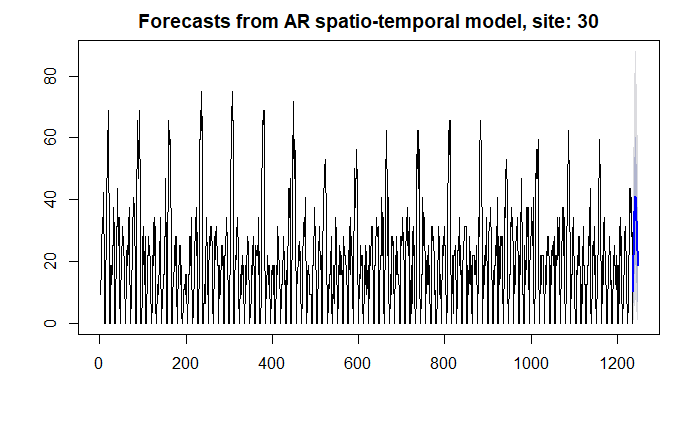

```r
plot(tmp)
```